# A UN Report on the Relationship between GDP and Life Expectancy

Patrick D. Schloss

2023-10-13

## Abstract

This report was prepared to the attention of the UN. It analyzes the relationship between a country’s GDP, its life expectancy, and CO2 emissions. Our goal is to determine to what degree a country’s economic strength or weakness is related to its public health status and impact on climate pollution. We hypothesize that both life expectancy and CO2 emissions increase with the country’s GDP.

## Plotting GDP by Life Expectancy

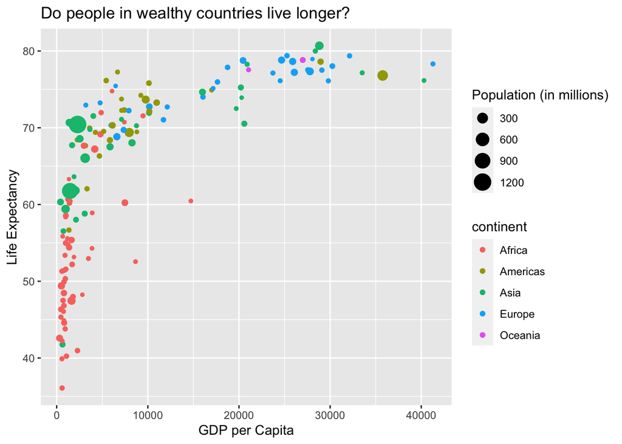

## Summary statistics

| Summary of data |  |
| --- | --- |
| Number of countries | 142 |
| Minimum GDP per capita | 312.2 |
| Maximum GDP per capita | 41283.2 |

| country | pop | continent | lifeExp | gdpPercap |
| --- | --- | --- | --- | --- |
| Australia | 18565243 | Oceania | 78.83 | 26997.94 |
| New Zealand | 3676187 | Oceania | 77.55 | 21050.41 |

## Exercises

#### Exercise 1:

Try googling how to create sections by using headers and sub-headers using Markdown. What do you find?

### Exercise 2:

Go ahead and do some online searches on how to do the following:

- Create a bullet point list with three items
- As the first item, write the name of your currently favorite programming language in bold
- As the second item, write the name of a function you have so far found most useful in italics
- As the third item, write one thing you want to learn next on your programming journey in bold and italics
- Turn your bullet point list into a numbered list
- Create a fourth list item and find an online guide and/or cheat sheet for basic Markdown syntax, write its name down here and hyperlink its URL

My bulleted list

- My favorite programming language is **R**
- The most useful function has been *group_by*
- The next thing I want to learn is *RNAseq analysis*